# Regressio reviireillä: Splitataan panta chull-reviireiksi ja niiden yksikäsitteisiksi paloiksi (v6.1: proper dates)

Tuomas R

2021-08-03

- v6.1: Expert territories active Jan - March, not just March

# Havaintoyksiköt

Samaan tyyliin regressiota tassu-havainnoille ehdolla GPS data. Tällä kertaa sen sijaan että havaintoyksikkö on 5x5km x 1kk ruudukko soluista $G(i,t)$ s.e. $|panta\cap G(i,t)|>0 \forall t$, tehdään reviiriajattelun mukainen tila-jaottelu

- Olkoon $R_i = cHull(panta_i)$ missä $panta_i$ on yksi panta-aineiston sarja
- Olkoon reviiri-solut $G_i = R_i \times [a_i,b_i]$ missä aika on $panta_i$ ajanjakso

Tehdään reviireihin jako ja tarkastellaan saadun ruudukon ominaisuuksia.

```r
# should not need to be run many times.
ww <- setwd("../data_not_public/")
source("4-gather-wolf-territories-v6.1.R")
setwd(ww)

series <- unique(panta$series)
nseries <- length(series)

cat( "sarjoja: ", nseries, "\n")
```

```
## sarjoja:  112
```

# Asiantuntija-arviot reviireistä

Asiantuntijat arvioivat vuosittain reviirit pohjaten kaikkeen tietoon (ml. gps-data).

- saatu 2017-2020 reviirit
- arvioit ovat kuluvan vuoden maaliskuun tilanteelle. Oletetaan että pätee vuoden alusta, merkataan siis päivämääriksi 1.1. - 31.3.

Jokaisessa datassa on

- polygoneina arvatut reviirit
- ihan eri muuttujanimet
- ainoa sama muuttuja on pinta-ala, joka triviaali laskea

Tiputetaan kaikki muu paitsi itse polygonit.

```r
#cthulls <- c(gpshulls, pri_hulls)
```

# Kuvauksia reviireistä

Kaikki GPS-otosyksiköt:

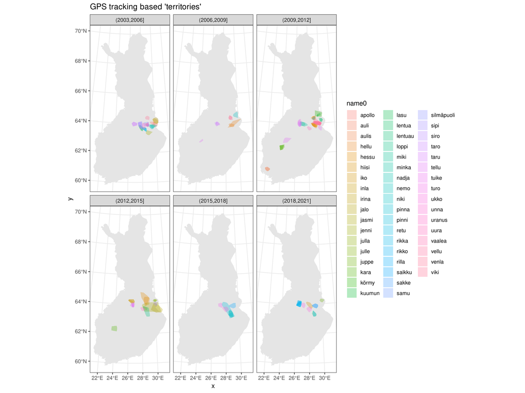

```r
panta %>% filter(!is.na(chull_rank)) %>%
  arrange(chull_rank) %>%
  mutate(years = cut(timestamp_y, seq(2003, 2021, by = 3))) %>%
  group_by(series) %>%
  mutate(tset = min(as.character(years))) %>%
  ggplot() +
  geom_sf(data = finland, col="gray90", fill="gray90") +
  geom_polygon(
               aes(x, y, fill = name0, group=series), alpha = .3)  +
  facet_wrap(~tset) +
  ggtitle("GPS tracking based 'territories'")
```

```r
#  geom_point(aes(x = x, y = y), size = 0.01, alpha = .3)
```

Kaikki priori-reviirit:

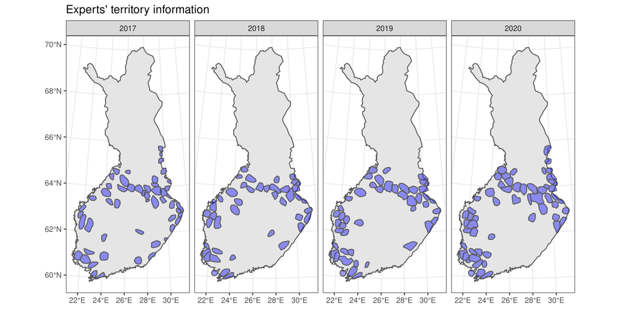

```r
# check
ggplot(pri_reviirit) +
  geom_sf(data=finland) +
  ggtitle("Experts' territory information") +
  geom_sf(fill = "blue", alpha=.4) + facet_wrap(~year, ncol = 4)
```

Pinta-alat ja aikajaksot:

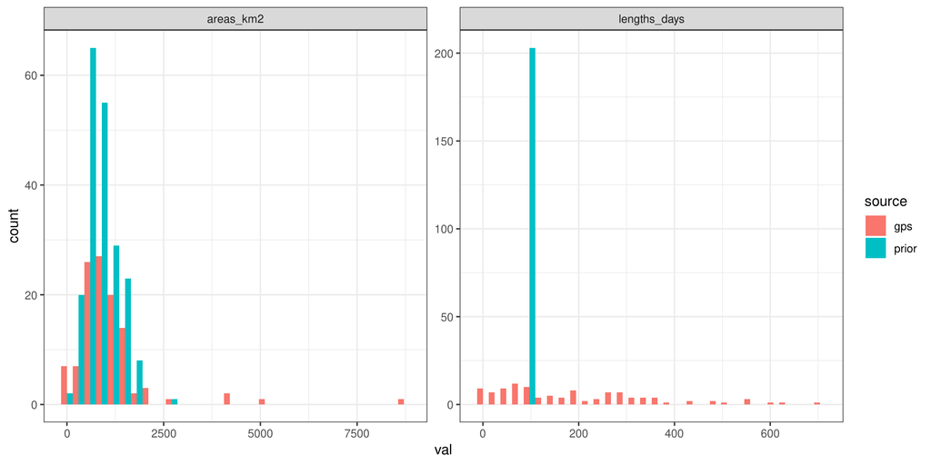

```r
# Shoelace
polyArea <- function(xy) {
  n <- nrow(xy)
  xy <- rbind(xy, xy[1,])
  -0.5 * sum( xy[1:n, 1]*xy[1:n+1, 2] - xy[1:n+1, 1]*xy[1:n, 2] )
}
stats <- tibble(series = names(cthulls),
                    areas_km2 = sapply(cthulls, function(h) polyArea(h$xy) ) / 1000^2,
                    lengths_days = sapply(cthulls, function(h) diff( as.POSIXct(h$bbox$tdate)  )) ) %>%
  mutate(source = c("gps", "prior")[1+grepl("^pri", series)] )%>%
  filter(! (series %in% bad_series))

stats %>%
  tidyr::gather(p, val, areas_km2:lengths_days) %>%
  ggplot(aes(val)) + geom_histogram(aes(fill = source), position = position_dodge()) + facet_wrap(~p, scales="free")
```

Largest, smallest, shortest (without pinna4) and longest series:

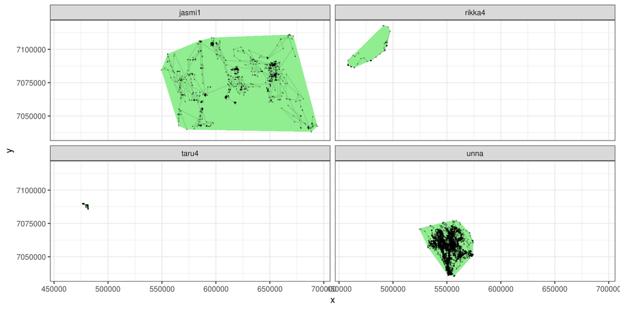

```r
longest <- panta %>% filter( series == stats$series[ which.max(stats$lengths_days) ] |
                             series == stats$series[ which.max(stats$areas_km2) ] |
                             series == stats$series[ which.min(stats$lengths_days) ] |
                             series == stats$series[ which.min(stats$areas_km2) ] )
pa <- longest#

pa %>%
  ggplot() +
  geom_polygon(data = . %>% filter(!is.na(chull_rank)) %>% arrange(chull_rank),
               aes(x, y), fill = "lightgreen") +
  geom_point(aes(x = x, y = y), size = 0.1, alpha = .3) +
  geom_path(aes(x = x, y = y), alpha = .1) +
  facet_wrap(~series)
```

Tarkastetaan aluiden päällekkäisyydet:

```r
# start with bounding box overlaps
# 0: times don't overla
# 1: times overlap, bboxes not
# 2: times and bboxes overlap
bbolap <- function(a, b) {
  # start with time
#  print(b)
  if(a[2,4] < b[1,4]) return(0)
  if(b[2,4] < a[1,4]) return(0)
  # time intervals intersect
  # then bounding box-wise
  for(i in 1:2)
  if(a[2,i] < b[1,i]) return(1)
  else if(b[2,i] < a[1,i]) return(1)
  # need to check polygon level...
  return(2)
}


series <- names(cthulls)
nseries <- length(series)
bboxes <- lapply(cthulls, getElement, "bbox")
pairs <- t( combn(1:nseries, 2 ))
bbicects <- apply(pairs, 1, function(ab) bbolap(bboxes[[ab[1]]], bboxes[[ab[2]]]) )

# those that both timewise and bbox wise intersect
pairs_bb <- pairs[which(bbicects == 2),]

# need to check these by polygon algorithm:
icects <- apply(pairs_bb, 1, function(ab) {
  a <- as.list(data.frame(cthulls[[ab[1]]]$xy))
  b <- as.list(data.frame(cthulls[[ab[2]]]$xy))
  polyclip::polyclip(a,b)
})

hit <- sapply(icects, length) > 0
pairs_overlap <- pairs_bb[ hit, ]

# areas of overlap
iareas <- -sapply(lapply(icects[hit], sapply, function(a)  polyArea(as.data.frame(a)) ), sum )/1000^2

table( overlapping_pairs= hit )
```

```
## overlapping_pairs
## FALSE  TRUE
##   113   188
```

Quite a bit of overlap :( Check a pair with two GPS-based ones:

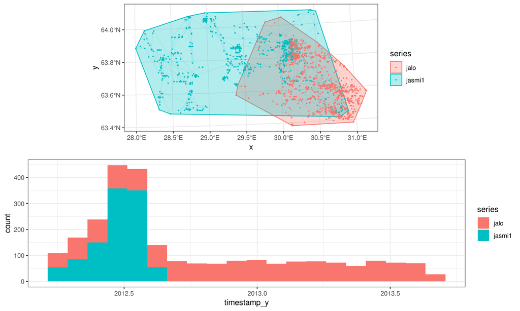

```r
both_gps <- apply(pairs_overlap < 111, 1, all)
iareas_gps <- iareas [ both_gps  ]
i <- order(iareas_gps, decreasing = TRUE)[1]
ex_series <- series[ pairs_overlap[both_gps,][i,]]
pa <- panta %>% filter( series %in% ex_series  )
v <- pa %>%
  ggplot() +
  geom_sf(data = topes %>% filter(series %in% ex_series), aes(col = series, fill = series), alpha = .3)   +
  geom_point(aes(x, y, col = series), size=.3) +
  geom_path(aes(x, y, col = series) , alpha = .1) #+ coord_fixed()

w <- pa %>% ggplot(aes(x = timestamp_y)) +
  geom_histogram(aes(fill = series), bins = 20)

gridExtra::grid.arrange(v, w, ncol=1)
```

Should split in the future? Go now without splitting, as only Boolean-conditioning is used.